# Andrew playing with category_change data

Andrew

16/12/2020

Let’s first draw some pictures of each of the trajectories for each chain in each condition. This only shows the ones that converged.

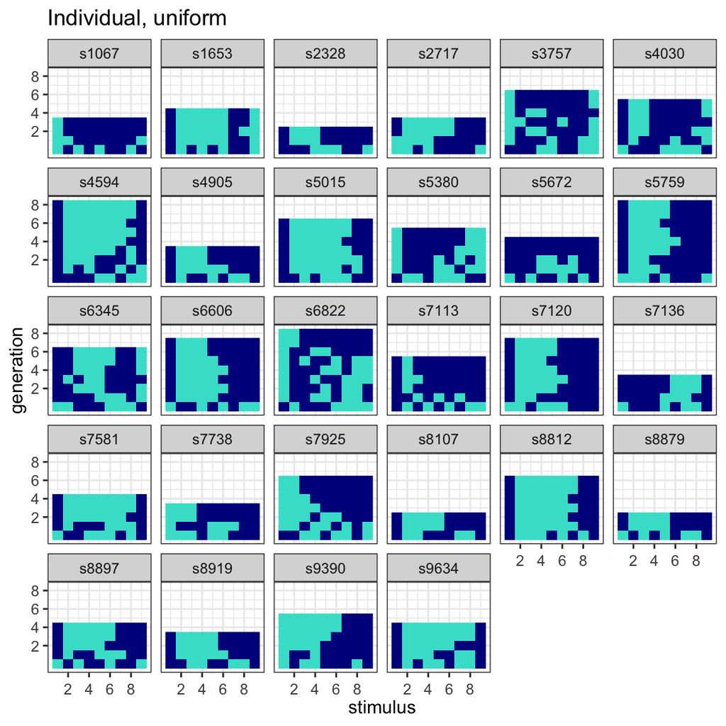

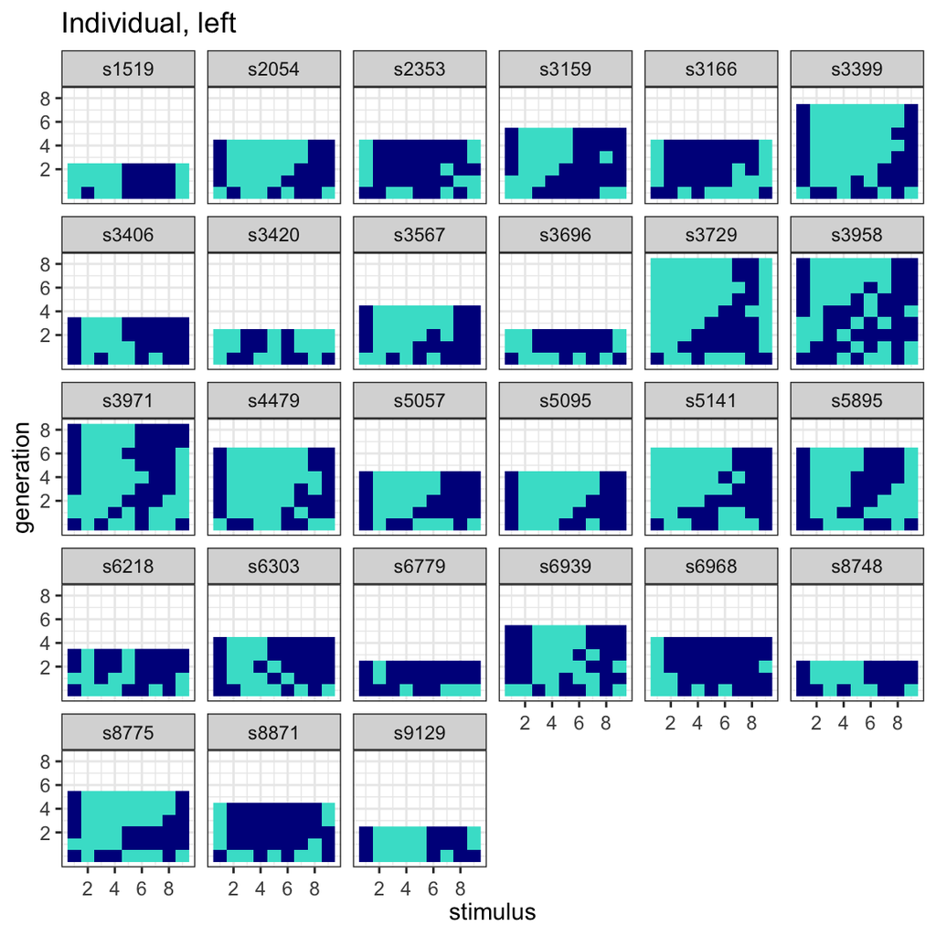

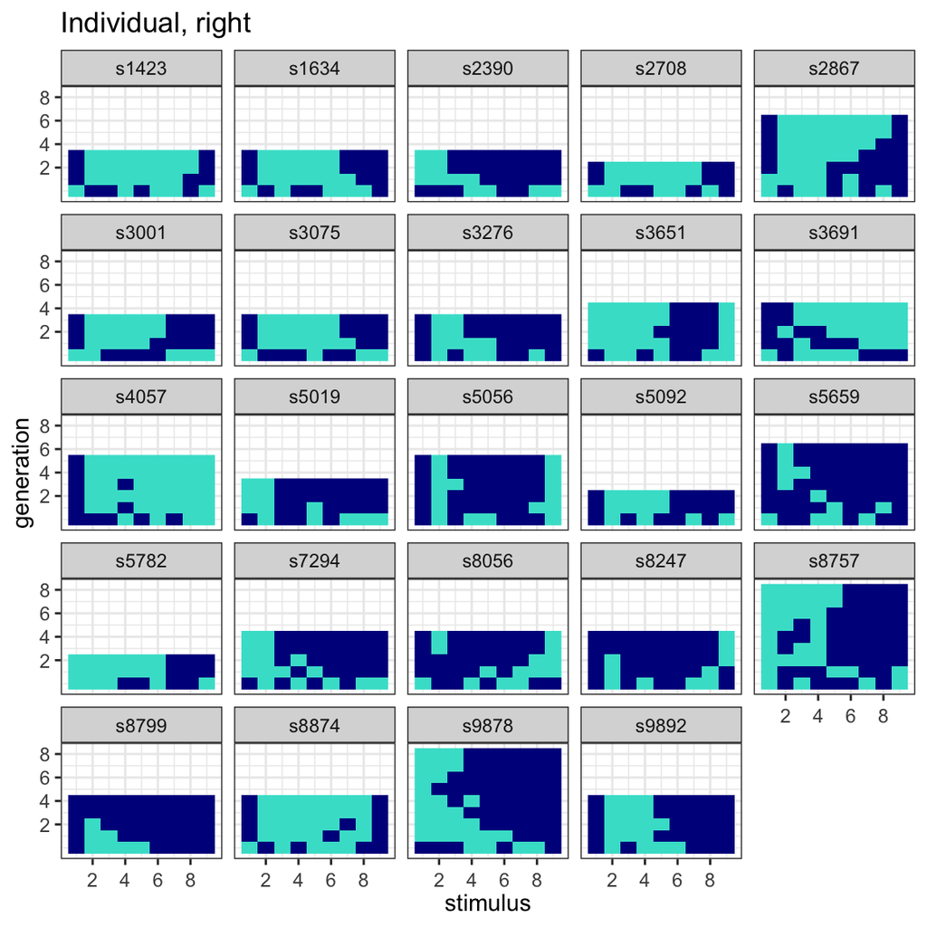

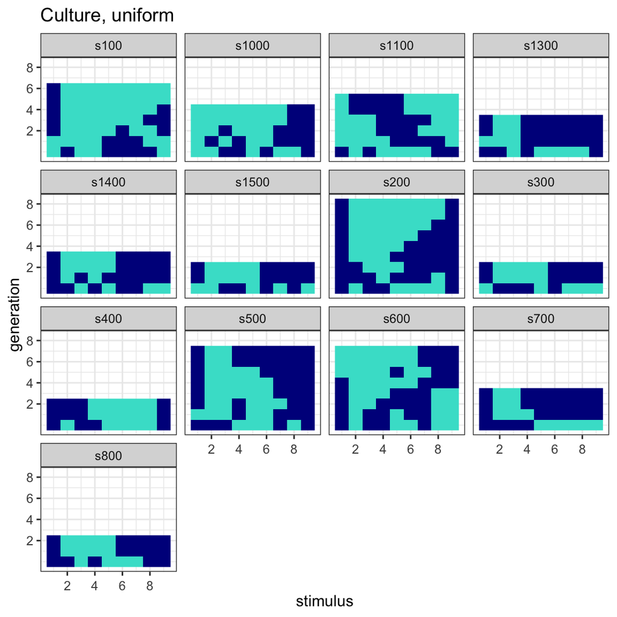

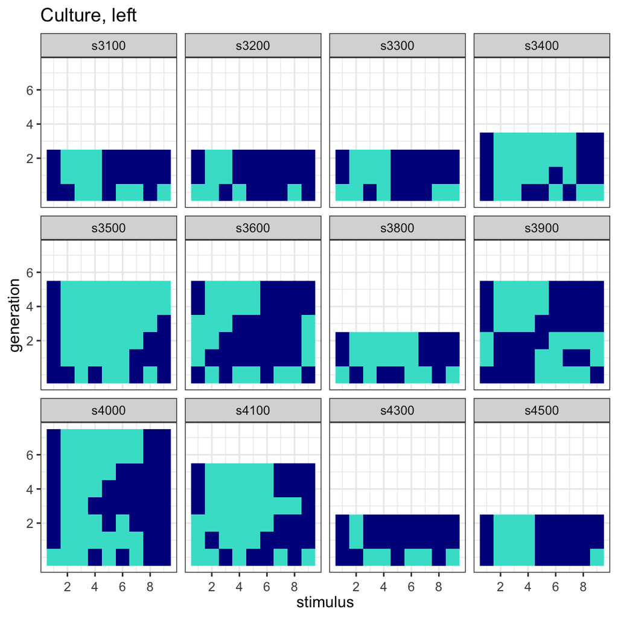

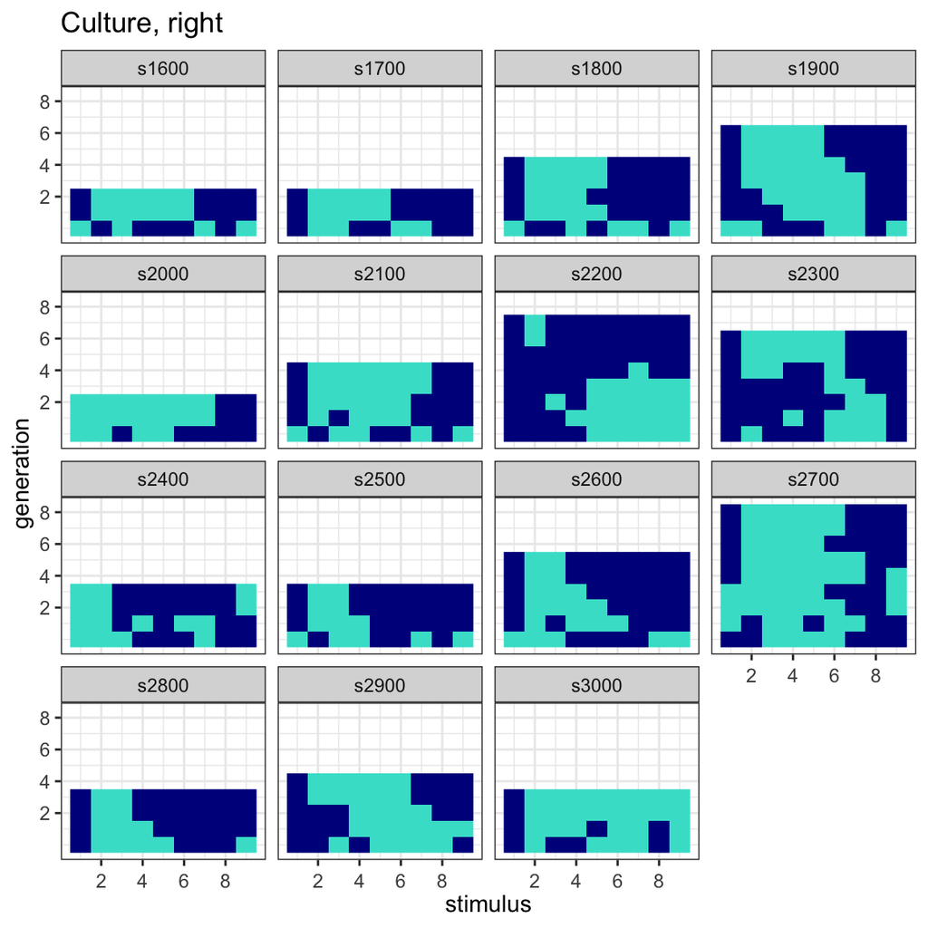

Now let’s look at just the final categorisation in each condition.

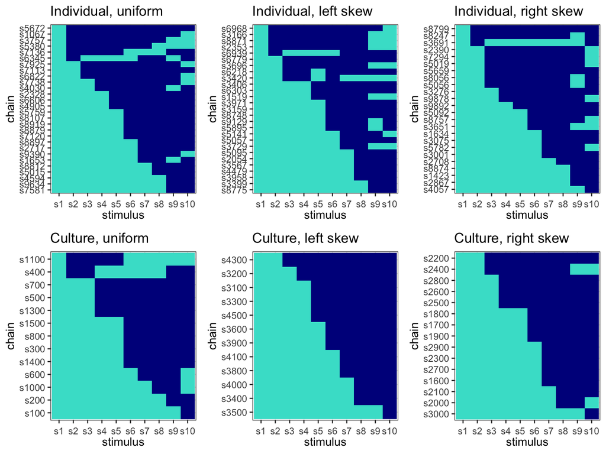

# Analyses on final generations

Let’s look at a bunch of things based on the final (converged) category for each chain. First, we can look at the aggregate classification by condition, averaged over everyone. Consistent with what we see above, there are no real strong boundaries or differences between conditions based on this metric.

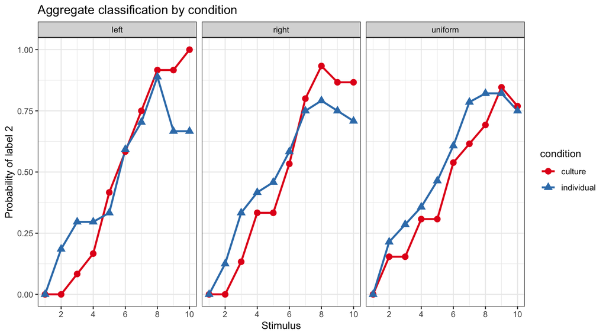

Now let’s see if the conditions differ in terms of the complexity (number of boundaries) in the final solution.

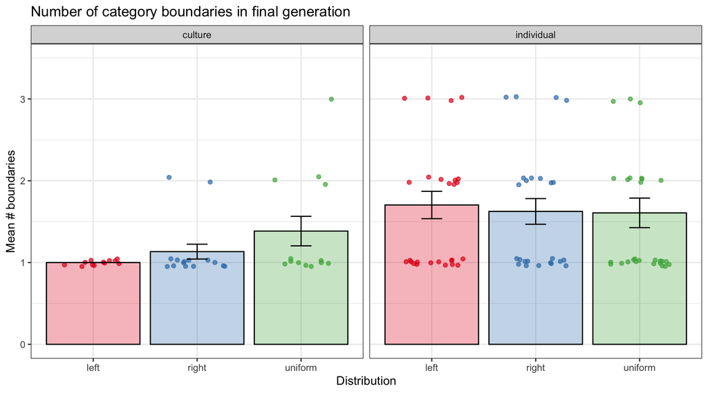

We did a two-way ANOVA with the outcome variable of number of boundaries and the two predictor variables of condition and distribution. The results revealed a significant main effect of condition (F(1,113)=10.26, p=0.002) but no main effect of distribution (F(2,113)=0.09, p=0.912) and no interaction (F(2,113)=0.87, p=0.42).

How did people do in terms of finding the optimum solution? Here we graph the distance of the final categorisation from the optimum of that # of boundaries.

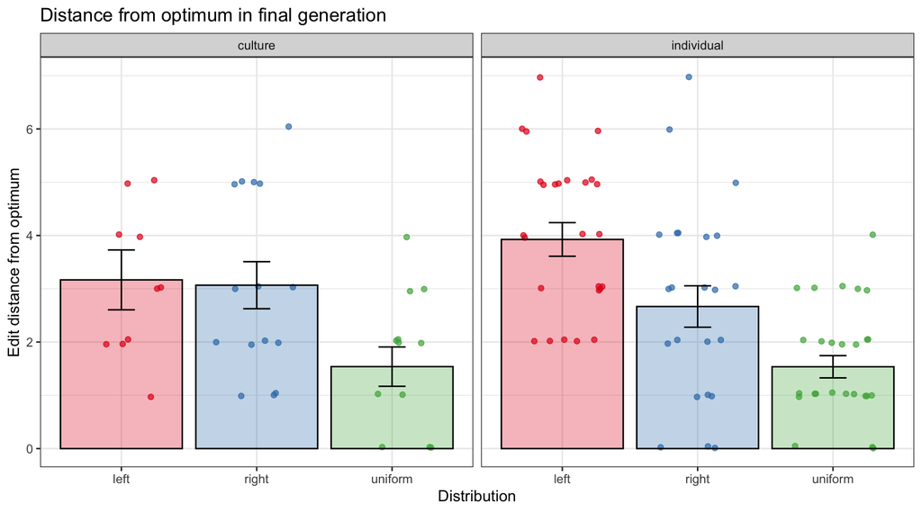

We did a two-way ANOVA with the outcome variable of distance from the optimum for that distribution and the two predictor variables of condition and distribution. The results revealed no significant main effect of condition (F(1,113)=0.1, p=0.758) but a significant main effect of distribution (F(2,113)=18.38, p=0) and no interaction (F(2,113)=1.17, p=0.314).

Looking at it, the main conclusion is that people weren’t sensitive to frequency, and always may have been assuming things were uniform, especially in the culture condition. The possible nuance here is that people were possibly a bit more sensitive to it in the individual condition, which would make sense given that they had many more trials in which to realise that some stimuli were much more common than others. If that’s the case, it’s not significant (the interaction isn’t), but the trend is visible. Another possibly interesting thing is that people seemed more sensitive to it in the right vs left skew condition - i.e. when the most frequent items were dark coloured rather than light. This is only an aside and not a big thing given the omnibus lack of significance, but for what it’s worth, I ran a t-test comparing just left and right within the individual condition and they are significantly different: t(45.74) =2.52, p=0.015, CI=[0.25,2.27]. All post-hoc and exploratory but suggests all together that (a) the reason people weren’t sensitive to frequency is that they didn’t realise some were more frequent, hence why individual was more sensitive than culture, and (b) there were perceptual biases that countered that realisation in the left-skew condition.

This suggests that people weren’t sensitive to frequency, and may have always been trying to optimise for what is best in the uniform condition. To test this let’s look at the distance from the optimum for uniform.

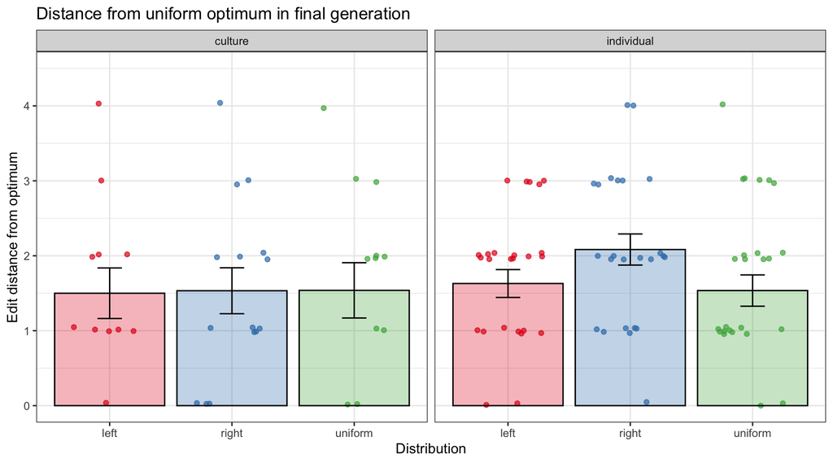

We did a two-way ANOVA with the outcome variable of distance from the optimum for that distribution and the two predictor variables of condition and distribution. As one would expect if people were optimising for the uniform always, there was no significant main effect of condition (F(1,113)=0.96, p=0.33) pr distribution (F(2,113)=1.16, p=0.316) and no interaction (F(2,113)=0.62, p=0.538).

Let’s also compare conditions in terms of how much they searched the space. As a first pass, let’s consider how many different categorisation schemes each chain used. Did individuals tend to search it more thoroughly?

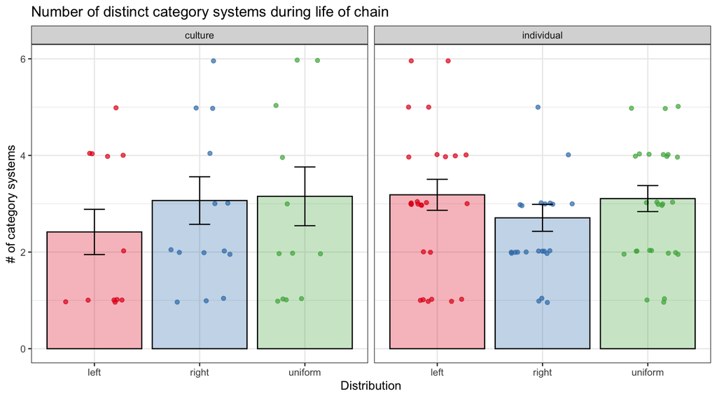

We did a two-way ANOVA with the outcome variable of number of distinct category systems explored by that chain and the two predictor variables of condition and distribution. There was no significant main effect of condition (F(1,113)=0.12, p=0.725) pr distribution (F(2,113)=0.27, p=0.761) and no interaction (F(2,113)=1.07, p=0.345).

How did conditions compare in how long they took to converge?

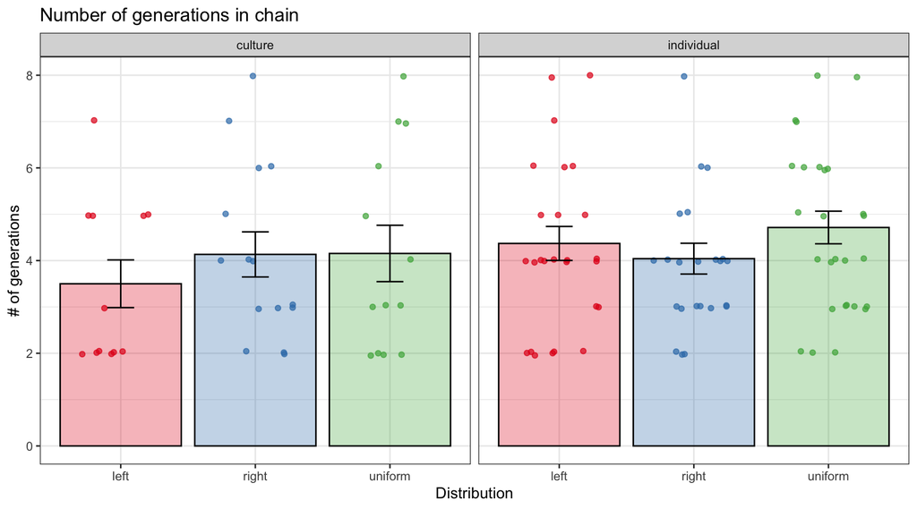

We did a two-way ANOVA with the outcome variable of number of generations in that chain and the two predictor variables of condition and distribution. There was no significant main effect of condition (F(1,113)=1.5, p=0.223) pr distribution (F(2,113)=0.73, p=0.483) and no interaction (F(2,113)=0.62, p=0.541).

# Analyses on full chains

Now let’s include all of our data and get a sense of what’s happening with all of it. This adds additional complexities because they are non-independent, but also gives a much richer picture. For this we include all of the data, not just the ones that converged.

First let’s pursue the idea that culture and individual differ in how they search the space. We saw that they didn’t really differ within chain (at least by the basic measure of number of distinct category systems) but they could still differ between chains, i.e., the individual condition chains are more distinct from each other (each cover different space) than the culture condition chains are.

One way of looking at this is just calculating the number of distinct category systems arise over all of the chains. Indeed, there are 169 in the individual condition and only 81 in the culture condition. It’s hard to tell how meaningful that is, however, because there are also a lot more chains in the individual condition: 90 compared to only 45. [That said, there are a lot more distinct people in the culture condition: 207 in culture, 90 in individual].

Anyway, a good way to figure out if this is actually different is to ask, if we limited ourselves to the equivalent number of chains as in the culture condition, how many dictinct category systems would we get? I test this below by drawing 500 random samples of 45 chains from the individual condition, and plotting their number of category systems each time.

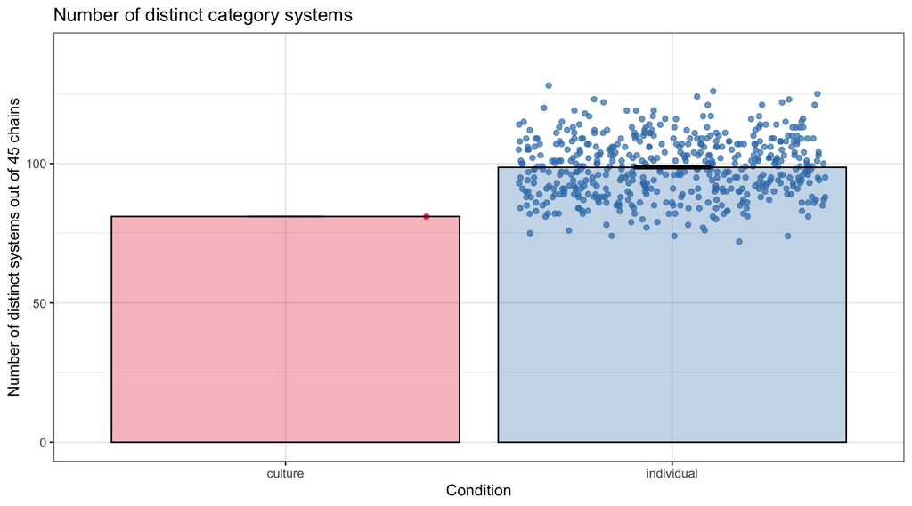

You pretty much don’t even need to do the stats on this, but for what it’s worth, a one-sample t-test comparing these sample in the individual condition to the observed number of distinct systems in the culture condition (81) is significant: (t(499) =37.31, p=0, CI=[97.72,99.58]. And only 3.8% of the samples had 81 or fewer distinct category systems.

In combination with the previous results showing that the converged category systems are more complex in the individual condition *and* that no single chain explores more in the individual condition, this suggests that individual chains are doing more exploring overall because they are more different from each other – which is probably because they are more complex, with more boundaries (there are more different systems possible with 3 boundaries than 1, for instance). We explore that next by breaking down in each condition how many unique systems of each number of boundaries are found.

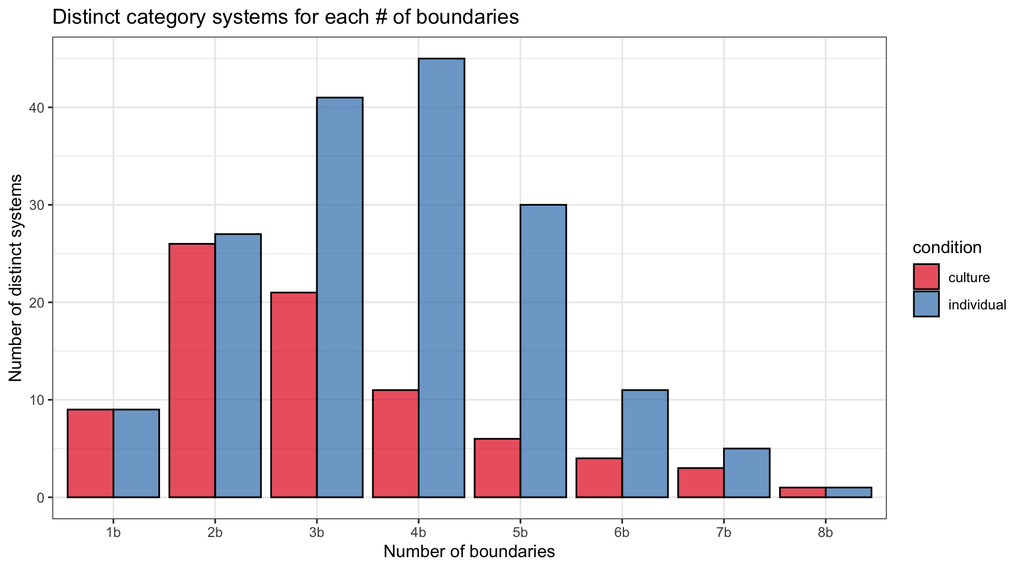

It’s pretty clear that this is exactly what’s happened. Both conditions completely explore the space of 1-boundary solutions, and most of the space of 2-boundary solutions, but in the individual condition there are many more 3-6 boundary solutions considered. FWIW, this is significant by a chi-squared test of independence (X^2(5) =17.55, p=0.004); FYI to do the test I collapsed the last three boundaries into one cell, so that all the cells were above five.

Another thing to look at is how chain complexity changes over time (generations). This is shown below and is super interesting. As expected, the culture conditions trim complexity more and more quickly – but this is especially pronounced in the left-skew and right-skew conditions (especially the right). This suggests that when the underlying landscape requires more complexity, individuals are more sensitive to it, but it’s not like they just keep complexity for no reason. (That said some of the individuals stopped before 5 or 6 or more generations, so it could also be that only some of the individuals were attuned to it, or we stopped them before they became attuned).

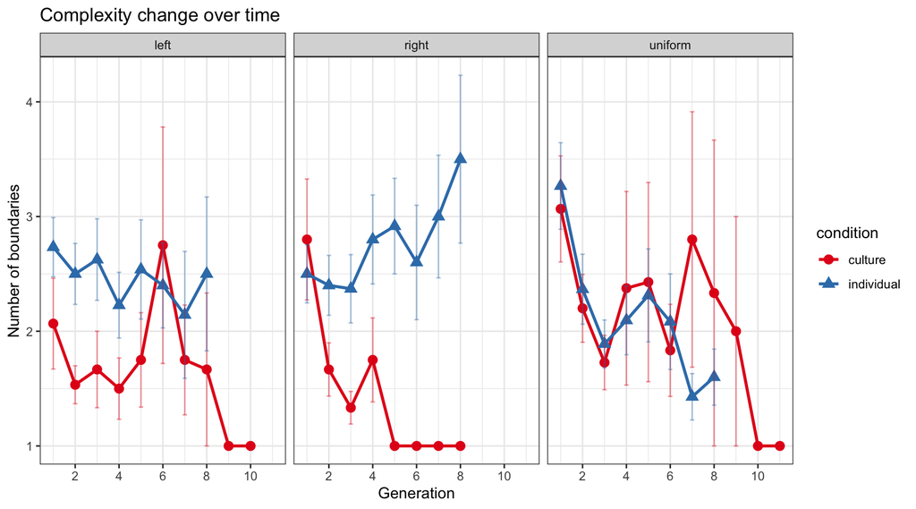

To do statistics on this requires a more complex model, because the same trajectory at different generations is non-independent. We therefore consider mixed effects models and select the best one according to AIC (where lower AIC = better).

```r
# mixed effects models
# simplest has only trajectory as a random effect
m1 <- lmer(nbound ~ (1|trajectory), data=dfull)
# only generation as fixed effect and trajectory as random; no interaction
m2 <- lmer(nbound ~ generation + (1|trajectory), data=dfull)
# generation and condition as fixed effects, and trajectory as random; no interaction
m3 <- lmer(nbound ~ condition+generation + (1|trajectory), data=dfull)
# generation and distribution as fixed effects, and trajectory as random; no interaction
m4 <- lmer(nbound ~ distribution+generation + (1|trajectory), data=dfull)
# generation,condition, and distribution as fixed effects, and trajectory as random; no int
m5 <- lmer(nbound ~ condition+distribution+generation + (1|trajectory), data=dfull)
# generation and condition as fixed effects, and trajectory as random; interaction
m6 <- lmer(nbound ~ condition*generation + (1|trajectory), data=dfull)
# generation and distribution as fixed effects, and trajectory as random; interaction
m7 <- lmer(nbound ~ distribution*generation + (1|trajectory), data=dfull)
# generation,condition, and distribution as fixed effects, and trajectory as random; int
m8 <- lmer(nbound ~ condition*distribution*generation + (1|trajectory), data=dfull)

AIC(m1,m2,m3,m4,m5,m6,m7,m8)
```

```
##    df      AIC
## m1  3 2195.701
## m2  4 2107.984
## m3  5 2105.199
## m4  6 2113.837
## m5  7 2111.116
## m6  6 2109.151
## m7  8 2115.393
## m8 14 2113.962
```

Looks like the model with the lowest AIC is m3, which has condition and generation as the fixed effects, trajectory as a random effect, and no interaction. in general adding distribution into the model does not help. We now interpret the parameters of the best-fitting model:

```r
summary(m3)
```

```
## Linear mixed model fit by REML ['lmerMod']
## Formula: nbound ~ condition + generation + (1 | trajectory)
##    Data: dfull
##
## REML criterion at convergence: 2095.2
##
## Scaled residuals:
##     Min      1Q  Median      3Q     Max
## -2.4477 -0.5660 -0.1872  0.3691  4.2309
##
## Random effects:
##  Groups     Name        Variance Std.Dev.
##  trajectory (Intercept) 1.199    1.095
##  Residual               1.040    1.020
## Number of obs: 642, groups:  trajectory, 135
##
## Fixed effects:
##                     Estimate Std. Error t value
## (Intercept)          2.45380    0.19281  12.726
## conditionindividual  0.54525    0.22182   2.458
## generation          -0.23590    0.02194 -10.754
##
## Correlation of Fixed Effects:
##             (Intr) cndtnn
## condtnndvdl -0.771
## generation  -0.332 -0.007
```

Note that lmer deliberately does not report p-values, but we can nevertheless interpret some of these coefficients. I think this means that the individual condition does result in more complexity (more boundaries), about 0.54 more than the culture condition on average when trajectory and generation is taken into account. And increasing generations have lower complexity, about 0.23 fewer boundaries with each additional generation.

We don’t have p-values but we can calculate the likelihood ratios. I think we can interpret this as meaning that the model with condition is 5.78 times more likely than the model without, and the model with generation is 133.02 times more likely than the model without

```r
# for condition
m3nocond <- lmer(nbound ~ generation + (1|trajectory), REML=F, data=dfull)
m3nogen <- lmer(nbound ~ condition + (1|trajectory), REML=F, data=dfull)
m3wboth <- lmer(nbound ~ condition+generation + (1|trajectory), REML=F, data=dfull)
LRcond <- (AIC(m3nocond)-AIC(m3wboth))*log2(exp(1))
LRcond
```

```
## [1] 5.783169
```

```r
LRgen <- (AIC(m3nogen)-AIC(m3wboth))*log2(exp(1))
LRgen
```

```
## [1] 133.0214
```

Let’s also look at the pattern of change across generation and by condition. Here the outcome variable is the number of items that changed from the previous mapping: zero indicates no change, ten would mean all of them changed label.

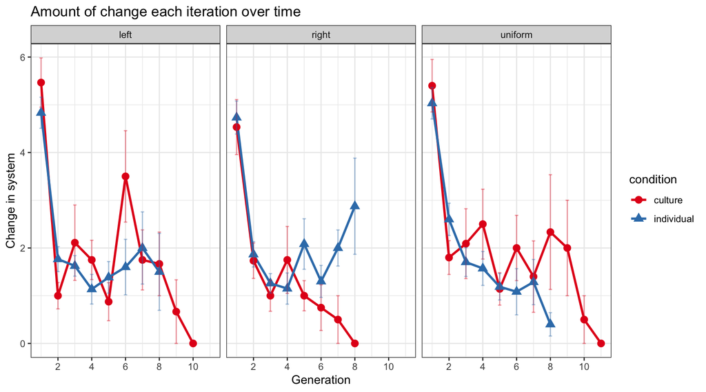

Looks like there wasn’t much difference by condition or distribution – perhaps with right individual, but keep in mind that there are only two people past generation 6 there so it’s not that meaningfl. Anyway, let’s run the statistics to make sure.

```r
# mixed effects models
# simplest has only trajectory as a random effect
m1 <- lmer(catchange ~ (1|trajectory), data=dfull)
# only generation as fixed effect and trajectory as random; no interaction
m2 <- lmer(catchange ~ generation + (1|trajectory), data=dfull)
# generation and condition as fixed effects, and trajectory as random; no interaction
m3 <- lmer(catchange ~ condition+generation + (1|trajectory), data=dfull)
# generation and distribution as fixed effects, and trajectory as random; no interaction
m4 <- lmer(catchange ~ distribution+generation + (1|trajectory), data=dfull)
# generation,condition, and distribution as fixed effects, and trajectory as random; no int
m5 <- lmer(catchange ~ condition+distribution+generation + (1|trajectory), data=dfull)
# generation and condition as fixed effects, and trajectory as random; interaction
m6 <- lmer(catchange ~ condition*generation + (1|trajectory), data=dfull)
# generation and distribution as fixed effects, and trajectory as random; interaction
m7 <- lmer(catchange ~ distribution*generation + (1|trajectory), data=dfull)
# generation,condition, and distribution as fixed effects, and trajectory as random; int
m8 <- lmer(catchange ~ condition*distribution*generation + (1|trajectory), data=dfull)

AIC(m1,m2,m3,m4,m5,m6,m7,m8)
```

```
##    df      AIC
## m1  3 2799.190
## m2  4 2669.768
## m3  5 2672.951
## m4  6 2674.427
## m5  7 2677.624
## m6  6 2678.014
## m7  8 2681.134
## m8 14 2689.467
```

As expected based on the graph, here the best-fit model is m2, which has just the random effect of trajectory and the fixed effect of generation. It’s becoming more learnable (i.e., fewer errors from generation to generation) over time at a similar rate across conditions. Put another way, the amount of change to the category structure is similar from one generation to another regardless of condition. So if individual conditions are searching over more space, it’s not because each step is larger - it’s just that different individuals end up going in different directions, whereas all of the culture changes went in similar directions (toward the simple one-boundary solutions).

```r
summary(m2)
```

```
## Linear mixed model fit by REML ['lmerMod']
## Formula: catchange ~ generation + (1 | trajectory)
##    Data: dfull
##
## REML criterion at convergence: 2661.8
##
## Scaled residuals:
##     Min      1Q  Median      3Q     Max
## -1.6678 -0.6858 -0.1602  0.5152  3.8542
##
## Random effects:
##  Groups     Name        Variance Std.Dev.
##  trajectory (Intercept) 0.3768   0.6139
##  Residual               3.3606   1.8332
## Number of obs: 642, groups:  trajectory, 135
##
## Fixed effects:
##             Estimate Std. Error t value
## (Intercept)  3.88427    0.14879   26.11
## generation  -0.49152    0.03625  -13.56
##
## Correlation of Fixed Effects:
##            (Intr)
## generation -0.787
```